# R Markdown Bike Rental Presentation with just graphs

2022-10-13

## The Bike Rental Project

A bike rental company based in Chicago has two types of consumers:

- Member
- Casual

They want to convert the Casual consumers into Member.

## Vision and Mission

#### *Vision*:

To convert Casual riders into Member riders

#### *Mission*:

The marketing team of the bike-rental company will come up with offers that would be targeted to the rider-type Casual. To achieve this a comparison needs to be made between the Casual vs Member to understand how the two groups use the bikes differently.

## Goals

### About 3,400,000 rows of data have been crunched to understand -

- How the rental bikes are used by days of the week by the two groups.
- How the variance of the bikes fluctuates according to months.
- What is the mean riding duration for the two groups.
- Is there a variance in direction taken for the two groups.

## Data Source

The data has been made available by Motivate International Inc. under this license - https://ride.divvybikes.com/data-license-agreement . 12 months data from April 2020 to March 2021 have been used for this project.

## Plot 1

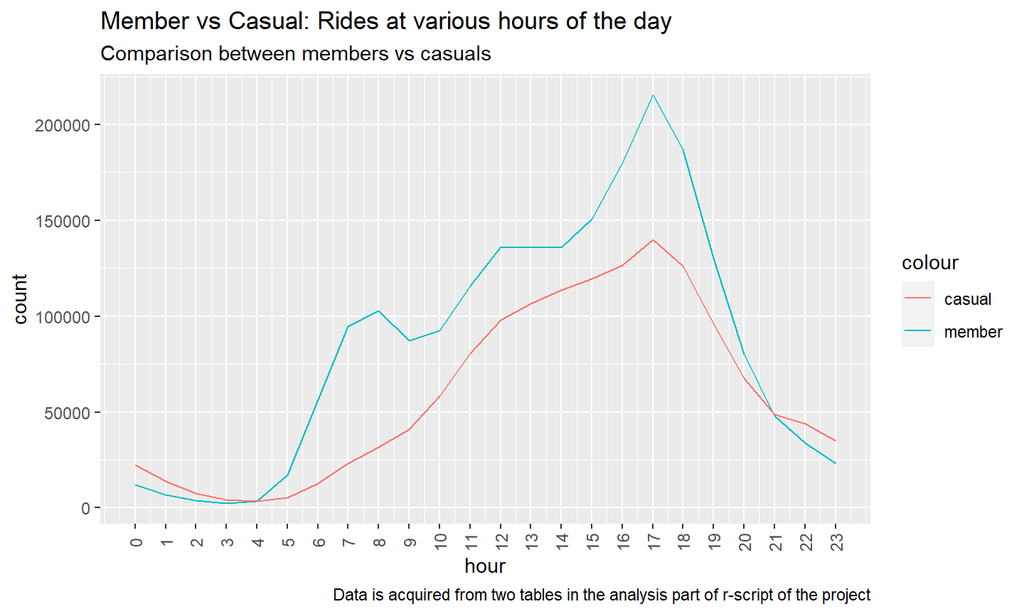

INSIGHT: We find out that casual riders do not peak in morning, they only peak in evening however there is a small spike in morning for members.

## Plot 2

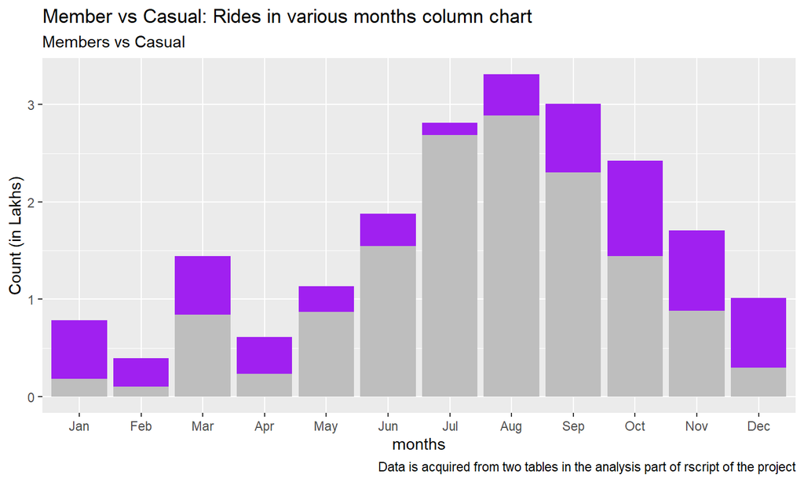

INSIGHT: Difference between no.of Member vs no.of Casual is very high for Jan, Dec. Members were much higher. It was moderately high for Nov and Oct. Difference was least for July.

## Plot 3

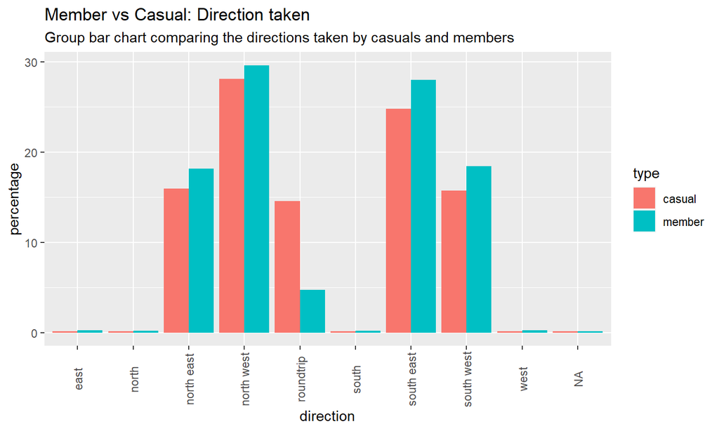

**INSIGHT: Casual take far more roundtrips than Member.**

## Plot 4

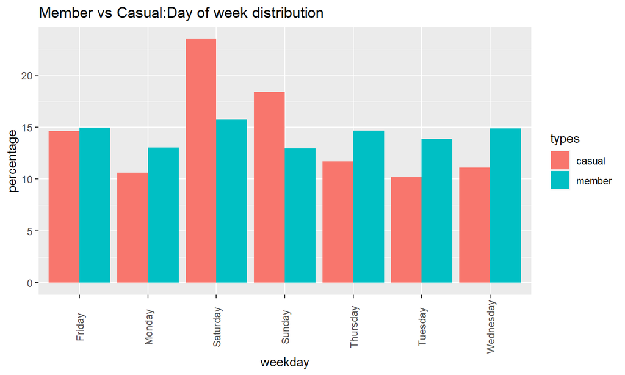

**INSIGHT: Member use everyday equivalently. Casual use mostly on Saturday, Sunday, closely followed by Friday.**

## Plot 5

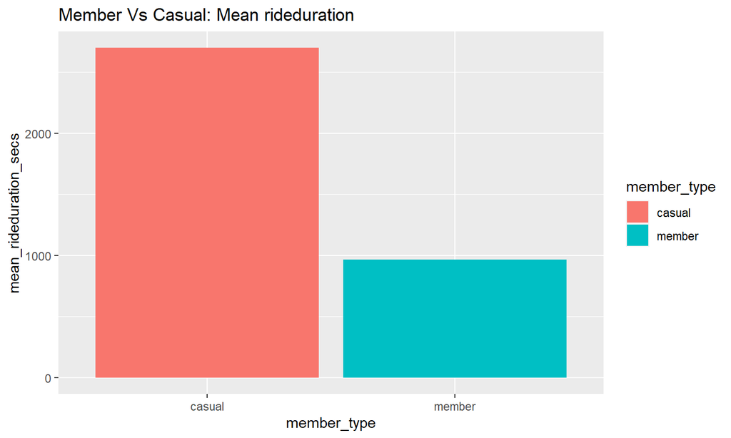

**INSIGHT: The mean of Casual is much higher(more than double) that of Member.**

## Plot 6

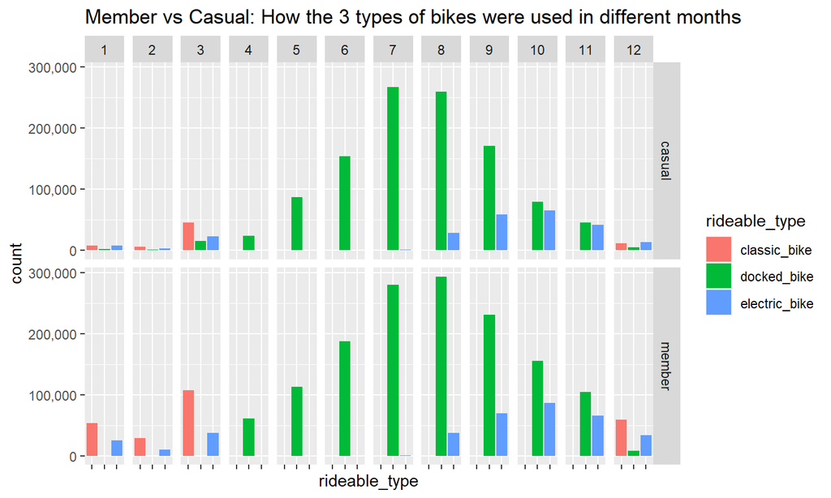

INSIGHT: - In Jan members used much more classic bikes compared to casuals. - In March casual who are less in number used docked bikes but none of the members used it. - In Dec comparatively a large set of members used classic bikes.

## Plot 7

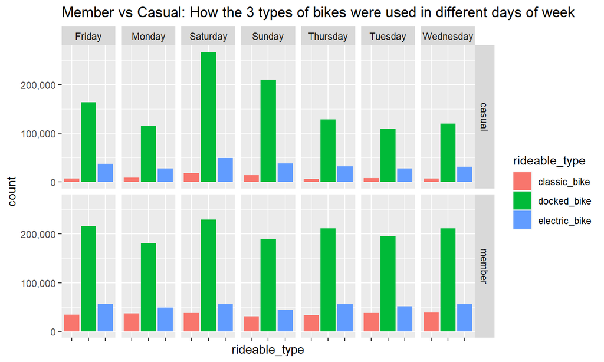

**INSIGHT: Electric bike consumption almost same for Member and Casual on Saturdays.**

## CONCLUSION

### Members use the bikes for:

**- They ride for shorter duration**

**- They rarely take roundtrips**

### Casual use the bikes for:

**- Rides mostly on weekends and summers**

**- They ride for longer duration**

**- They often take roundtrips**